# VKOR_abundance_activity_analysis_pipeline

#### Figure 3b: Windowed average of charged scores to determine topology for abundance scores

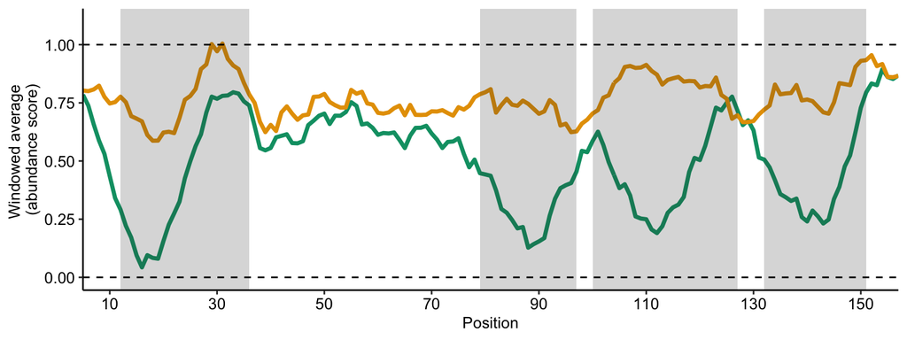

```r
#get an average abundance score at a position based on mut_class
window_plot_data_abundance<-dplyr::select(vkor_variants,position,abundance_score,class,mut_class)
window_plot_data_abundance<-window_plot_data_abundance[window_plot_data_abundance$class != "synonymous",]
window_plot_data_abundance<-window_plot_data_abundance[!is.na(window_plot_data_abundance$abundance_score),]
window_plot_data_abundance<-window_plot_data_abundance[!is.na(window_plot_data_abundance$mut_class),]
window_plot_data_final<-ddply(window_plot_data_abundance,c("position", "mut_class"),summarise,mean=mean(abundance_score))

#make dataframes for each mut_class
charged_df<-(window_plot_data_final[which(window_plot_data_final$mut_class == "Charged"),])
aliphatic_df<-(window_plot_data_final[which(window_plot_data_final$mut_class == "Aliphatic uncharged"),])
aromatic_df<-(window_plot_data_final[which(window_plot_data_final$mut_class == "Aromatic"),])
proline_df<-(window_plot_data_final[which(window_plot_data_final$mut_class == "Proline"),])
hydrophilic_df<-(window_plot_data_final[which(window_plot_data_final$mut_class == "Hydrophilic uncharged"),])
nonpolar_df<-(window_plot_data_final[which(window_plot_data_final$mut_class == "Nonpolar uncharged"),])
nonsense_df<-(window_plot_data_final[which(window_plot_data_final$mut_class == "Nonsense"),])

#need to fill-in missing positions, create a seq of 2 to 163, then merge with orig df
pos_df<-data.frame(position = seq(from=2, to=max(window_plot_data_final$position)))
charged_df<-merge(pos_df, charged_df, all.x = TRUE)
aliphatic_df<-merge(pos_df, aliphatic_df, all.x = TRUE)
aromatic_df<-merge(pos_df, aromatic_df, all.x = TRUE)
proline_df<-merge(pos_df, proline_df, all.x = TRUE)
hydrophilic_df<-merge(pos_df, hydrophilic_df, all.x = TRUE)
nonpolar_df<-merge(pos_df, nonpolar_df, all.x = TRUE)
nonsense_df<-merge(pos_df, nonsense_df, all.x = TRUE)


#Use rollapply to calculate windowed average
charged_window<-rollapply(as.numeric(charged_df$mean), width = 10,FUN = mean, align = "center", na.rm=TRUE)
aliphatic_window<-rollapply(as.numeric(aliphatic_df$mean), width = 10,FUN = mean, align = "center", na.rm=TRUE)
aromatic_window<-rollapply(as.numeric(aromatic_df$mean), width = 10,FUN = mean, align = "center", na.rm=TRUE)
proline_window<-rollapply(as.numeric(proline_df$mean), width = 10,FUN = mean, align = "center", na.rm=TRUE)
hydrophilic_window<-rollapply(as.numeric(hydrophilic_df$mean), width = 10,FUN = mean, align = "center", na.rm=TRUE)
nonpolar_window<-rollapply(as.numeric(nonpolar_df$mean), width = 10,FUN = mean, align = "center", na.rm=TRUE)
nonsense_window<-rollapply(as.numeric(nonsense_df$mean), width = 10,FUN = mean, align = "center", na.rm=TRUE)


charged_window<-data.frame(pos=seq(from=5, to=157, by=1),mean=charged_window)
charged_window$class<-"charged"
aliphatic_window<-data.frame(pos=seq(from=5, to=157, by=1),mean=aliphatic_window)
aliphatic_window$class<-"aliphatic"
aromatic_window<-data.frame(pos=seq(from=5, to=157, by=1),mean=aromatic_window)
aromatic_window$class<-"aromatic"
proline_window<-data.frame(pos=seq(from=5, to=157, by=1),mean=proline_window)
proline_window$class<-"proline"
hydrophilic_window<-data.frame(pos=seq(from=5, to=157, by=1),mean=hydrophilic_window)
hydrophilic_window$class<-"hydrophilic"
nonpolar_window<-data.frame(pos=seq(from=5, to=157, by=1),mean=nonpolar_window)
nonpolar_window$class<-"nonpolar"
nonsense_window<-data.frame(pos=seq(from=5, to=157, by=1),mean=nonsense_window)
nonsense_window$class<-"nonsense"

#combine all these dataframes back together
complete_window_data<-rbind(charged_window, aliphatic_window, aromatic_window, proline_window, hydrophilic_window, nonpolar_window,nonsense_window)

#charged amino acids with aliphatics as a negative control
charged_window_score_plot_abundance<-ggplot() +geom_line(data=subset(complete_window_data,class=="charged"), aes (x=pos, y = mean),colour="#009E73",size=1.25)+geom_line(data=subset(complete_window_data,class=="aliphatic"), aes (x=pos, y = mean),colour="#E69F00",size=1.25)+ scale_x_continuous(breaks = seq(10,150,20),limits=c(5,157),expand = c(0, 0))+scale_y_continuous(breaks=seq(0,1,0.25), limits=c(0,1.1))+annotate("rect", xmin=12, xmax=36, ymin=-Inf, ymax=Inf, alpha=0.2, fill="grey20")+annotate("rect", xmin=79, xmax=97, ymin=-Inf, ymax=Inf, alpha=0.2, fill="grey20")+annotate("rect", xmin=100, xmax=127, ymin=-Inf, ymax=Inf, alpha=0.2, fill="grey20")+annotate("rect", xmin=132, xmax=151, ymin=-Inf, ymax=Inf, alpha=0.2, fill="grey20")+geom_hline(yintercept=1,linetype="dashed")+geom_hline(yintercept = 0,linetype="dashed")+xlab("Position")+ylab("Windowed average \n(abundance score)")+
  theme(axis.text.x =element_text(size=10,color="black"),
        axis.text.y=element_text(size=10,color="black"),
        axis.title=element_text(size=10,color="black"))
plot(charged_window_score_plot_abundance)
```

```r
ggsave("Output/charged_window_plot_abundance.pdf", charged_window_score_plot_abundance, height = 1.25, width = 4.35)
```

#### Figure 3c: Windowed average of charged scores to determine topology for activity scores

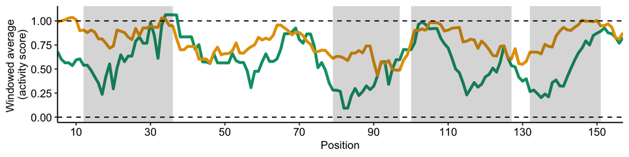

```r
#get an average activity score at a position based on mut_class
window_plot_data_activity<-dplyr::select(vkor_variants,position,activity_score,class,mut_class)
window_plot_data_activity<-window_plot_data_activity[window_plot_data_activity$class != "synonymous",]
window_plot_data_activity<-window_plot_data_activity[!is.na(window_plot_data_activity$activity_score),]
window_plot_data_activity<-window_plot_data_activity[!is.na(window_plot_data_activity$mut_class),]
window_plot_data_final<-ddply(window_plot_data_activity,c("position", "mut_class"),summarise,mean=mean(activity_score))

#make dataframes for each mut_class
charged_df<-(window_plot_data_final[which(window_plot_data_final$mut_class == "Charged"),])
aliphatic_df<-(window_plot_data_final[which(window_plot_data_final$mut_class == "Aliphatic uncharged"),])
aromatic_df<-(window_plot_data_final[which(window_plot_data_final$mut_class == "Aromatic"),])
proline_df<-(window_plot_data_final[which(window_plot_data_final$mut_class == "Proline"),])
hydrophilic_df<-(window_plot_data_final[which(window_plot_data_final$mut_class == "Hydrophilic uncharged"),])
nonpolar_df<-(window_plot_data_final[which(window_plot_data_final$mut_class == "Nonpolar uncharged"),])
nonsense_df<-(window_plot_data_final[which(window_plot_data_final$mut_class == "Nonsense"),])


#need to fill-in missing positions, create a seq of 2 to 163, then merge with orig df
pos_df<-data.frame(position = seq(from=2, to=max(window_plot_data_final$position)))
charged_df<-merge(pos_df, charged_df, all.x = TRUE)
aliphatic_df<-merge(pos_df, aliphatic_df, all.x = TRUE)
aromatic_df<-merge(pos_df, aromatic_df, all.x = TRUE)
proline_df<-merge(pos_df, proline_df, all.x = TRUE)
hydrophilic_df<-merge(pos_df, hydrophilic_df, all.x = TRUE)
nonpolar_df<-merge(pos_df, nonpolar_df, all.x = TRUE)
nonsense_df<-merge(pos_df, nonsense_df, all.x = TRUE)


#Use rollapply to calculate windowed average
charged_window<-rollapply(as.numeric(charged_df$mean), width = 10,FUN = mean, align = "center", na.rm=TRUE)
aliphatic_window<-rollapply(as.numeric(aliphatic_df$mean), width = 10,FUN = mean, align = "center", na.rm=TRUE)
aromatic_window<-rollapply(as.numeric(aromatic_df$mean), width = 10,FUN = mean, align = "center", na.rm=TRUE)
proline_window<-rollapply(as.numeric(proline_df$mean), width = 10,FUN = mean, align = "center", na.rm=TRUE)
hydrophilic_window<-rollapply(as.numeric(hydrophilic_df$mean), width = 10,FUN = mean, align = "center", na.rm=TRUE)
nonpolar_window<-rollapply(as.numeric(nonpolar_df$mean), width = 10,FUN = mean, align = "center", na.rm=TRUE)
nonsense_window<-rollapply(as.numeric(nonsense_df$mean), width = 10,FUN = mean, align = "center", na.rm=TRUE)


charged_window<-data.frame(pos=seq(from=5, to=157, by=1),mean=charged_window)
charged_window$class<-"charged"
aliphatic_window<-data.frame(pos=seq(from=5, to=157, by=1),mean=aliphatic_window)
aliphatic_window$class<-"aliphatic"
aromatic_window<-data.frame(pos=seq(from=5, to=157, by=1),mean=aromatic_window)
aromatic_window$class<-"aromatic"
proline_window<-data.frame(pos=seq(from=5, to=157, by=1),mean=proline_window)
proline_window$class<-"proline"
hydrophilic_window<-data.frame(pos=seq(from=5, to=157, by=1),mean=hydrophilic_window)
hydrophilic_window$class<-"hydrophilic"
nonpolar_window<-data.frame(pos=seq(from=5, to=157, by=1),mean=nonpolar_window)
nonpolar_window$class<-"nonpolar"
nonsense_window<-data.frame(pos=seq(from=5, to=157, by=1),mean=nonsense_window)
nonsense_window$class<-"nonsense"

#combine all these dataframes back together
complete_window_data<-rbind(charged_window, aliphatic_window, aromatic_window, proline_window, hydrophilic_window, nonpolar_window, nonsense_window)

#charged amino acids and aliphatics as negative control
charged_window_score_plot_activity<-ggplot()+geom_line(data=subset(complete_window_data,class=="charged"), aes (x=pos, y = mean),colour="#009E73",size=1.25)+geom_line(data=subset(complete_window_data,class=="aliphatic"), aes (x=pos, y = mean),colour="#E69F00",size=1.25)+ scale_x_continuous(breaks = seq(10,150,20),limits=c(5,157),expand = c(0, 0))+scale_y_continuous(breaks=seq(0,1,0.25), limits=c(0,1.1))+xlab("Position")+ ylab("Windowed average \n(activity score)")+annotate("rect", xmin=12, xmax=36, ymin=-Inf, ymax=Inf, alpha=0.2, fill="grey20")+annotate("rect", xmin=79, xmax=97, ymin=-Inf, ymax=Inf, alpha=0.2, fill="grey20")+annotate("rect", xmin=100, xmax=127, ymin=-Inf, ymax=Inf, alpha=0.2, fill="grey20")+annotate("rect", xmin=132, xmax=151, ymin=-Inf, ymax=Inf, alpha=0.2, fill="grey20")+geom_hline(yintercept = 1,linetype="dashed")+geom_hline(yintercept = 0,linetype="dashed")+
  theme(axis.text.x =element_text(size=10,color="black"),
        axis.text.y=element_text(size=10,color="black"),
        axis.title=element_text(size=10,color="black"))
plot(charged_window_score_plot_activity)
```

```r
ggsave("Output/charged_window_plot_activity.pdf", charged_window_score_plot_activity, height = 1.25, width = 4.35)
```

#### Figure 3d: Plotting of evolutionary coupling data secondary structure

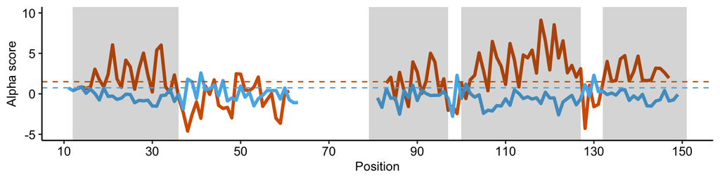

```r
evo_couplings_secondary_structure<-read.csv("vkor_EVcouplings_2ndary_structure_prediction.csv",header=TRUE)
colnames(evo_couplings_secondary_structure)<-c("position","start","alpha","beta","alpha_call","beta_call")

secondary_structure_plot<-ggplot(evo_couplings_secondary_structure)+geom_line(aes(x=position,y=alpha),colour="#D55E00",size=1.25)+geom_line(aes(x=position,y=beta),colour="#56B4E9",size=1.25)+ scale_x_continuous(breaks = seq(10,150,20),limits=c(5,157),expand = c(0, 0))+scale_y_continuous(breaks=seq(-5,10,5), limits=c(-5,10))+xlab("Position")+ ylab("Alpha score")+annotate("rect", xmin=12, xmax=36, ymin=-Inf, ymax=Inf, alpha=0.2, fill="grey20")+annotate("rect", xmin=79, xmax=97, ymin=-Inf, ymax=Inf, alpha=0.2, fill="grey20")+annotate("rect", xmin=100, xmax=127, ymin=-Inf, ymax=Inf, alpha=0.2, fill="grey20")+annotate("rect", xmin=132, xmax=151, ymin=-Inf, ymax=Inf, alpha=0.2, fill="grey20")+geom_hline(yintercept = 0.75,linetype="dashed",colour="#56B4E9")+geom_hline(yintercept = 1.5,linetype="dashed",colour="#D55E00")+
  theme(axis.text.x =element_text(size=10,color="black"),
        axis.text.y=element_text(size=10,color="black"),
        axis.title=element_text(size=10,color="black"))
plot(secondary_structure_plot)
```

```r
ggsave("Output/evolutionary_couplings_secondary_structure_prediction.pdf", secondary_structure_plot, height = 1.25, width = 4.1)
```

#### Figure 3d: Plotting of evolutionary coupling data tertiary structure

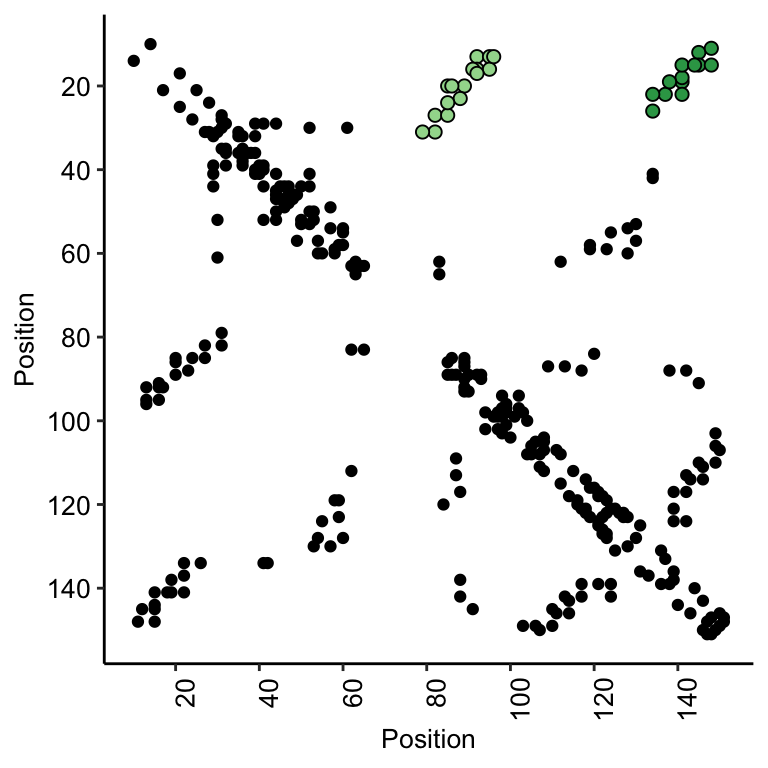

```r
evo_couplings_3D_contacts<-read.csv("vkor_EVcouplings_3d_contact_predictions.csv",header=TRUE)

evo_couplings_contact_map<-ggplot()+geom_point(data=subset(evo_couplings_3D_contacts, probability> 0.7),aes(x=j,y=i))+geom_point(data=subset(evo_couplings_3D_contacts, probability> 0.7),aes(x=i,y=j))+geom_point(data=subset(evo_couplings_3D_contacts, probability> 0.7 & i<30 & j>130),aes(x=j,y=i),fill="#31a354",shape=21,size=2)+geom_point(data=subset(evo_couplings_3D_contacts, probability> 0.7 & i<35 & j<100 & j>75),aes(x=j,y=i),fill="#a1d99b",shape=21,size=2)+scale_x_continuous(breaks=seq(0,160,20))+scale_y_reverse(breaks=seq(0,160,20))+xlab("Position")+ ylab("Position")+
  theme(axis.text.x =element_text(size=10,color="black",angle=90,hjust=0.95),
        axis.text.y=element_text(size=10,color="black"),
        axis.title=element_text(size=10,color="black"))
plot(evo_couplings_contact_map)
```

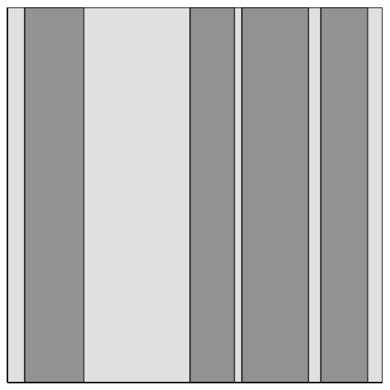

```r
ggsave("Output/evolutionary_couplings_contact_map.pdf", evo_couplings_contact_map, height = 2.5, width = 2.5)

#mini model of topology to go on top

vkor_architecture_schematic_4TM_mini <- ggplot() +
geom_rect(aes(xmin = 5, xmax = 12, ymin = 0, ymax = 5), color = NA, fill = "grey80", alpha = 0.5) +
geom_rect(aes(xmin = 12, xmax = 36, ymin = 0, ymax = 5), color = "grey20", fill = "grey20", alpha = 0.5) +
geom_rect(aes(xmin = 36, xmax = 79, ymin = 0, ymax = 5), color = NA, fill = "grey80", alpha = 0.5) +
geom_rect(aes(xmin = 79, xmax = 97, ymin = 0, ymax = 5), color = "grey20", fill = "grey20", alpha = 0.5) +
 geom_rect(aes(xmin = 97, xmax = 100, ymin = 0, ymax = 5), color = NA, fill = "grey80", alpha = 0.5) +
 geom_rect(aes(xmin = 100, xmax = 127, ymin = 0, ymax = 5), color = "grey20", fill = "grey20", alpha = 0.5) +
 geom_rect(aes(xmin = 127, xmax = 132, ymin = 0, ymax = 5), color = NA, fill = "grey80", alpha = 0.5) +
 geom_rect(aes(xmin = 132, xmax = 151, ymin = 0, ymax = 5), color = "grey20", fill = "grey20", alpha = 0.5) +
 geom_rect(aes(xmin = 151, xmax = 157, ymin = 0, ymax = 5), color = NA, fill = "grey80", alpha = 0.5) +
geom_segment(aes(x = 5, y = 0, xend = 157), yend = 0, size = 0.5) +geom_segment(aes(x = 5, y = 0, xend = 5), yend = 5, size = 0.5)+geom_segment(aes(x = 157, y = 0, xend = 157), yend = 5, size = 0.5)+geom_segment(aes(x = 5, y = 5, xend = 157), yend = 5, size = 0.5)+scale_x_continuous(breaks = NULL, expand = c(0,0)) +
scale_y_continuous(breaks = NULL, expand = c(0,0)) + xlab(NULL) + ylab(NULL)+theme(axis.text.x=element_blank())
plot(vkor_architecture_schematic_4TM_mini)
```

```r
ggsave(file = "Output/vkor_architecture_schematic_4TM_mini.pdf", vkor_architecture_schematic_4TM_mini, height =0.3, width = 2)
```

#### Figure 3h: how do VAMP-seq scores from TMDs compare to Sec61 delta delta Gs

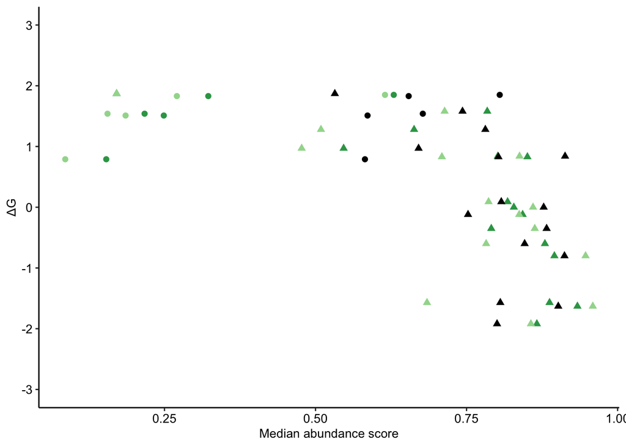

```r
elazar_data<-read.table("elazar_insertion_energies.csv",sep=',',header=TRUE)

#rename columns
colnames(elazar_data)<-c("end","delta_G")

#merge by "end" column with vkor_residue_median
vkor_residue_median_TMDs_agreed <- ddply(subset(vkor_variants, class == "missense" & specific_domain %in% c("TM1","TM2","TM3") & !(is.na(abundance_score)))[,c("end","abundance_score")], "end", numcolwise(median))
vkor_residue_median_TMD2 <- ddply(subset(vkor_variants, class == "missense" & specific_domain== "TM2" & !(is.na(abundance_score)))[,c("end","abundance_score","mut_class")], "end", numcolwise(median))
vkor_residue_median_non_TMD <- ddply(subset(vkor_variants, class == "missense" & specific_domain %in% c("long_ER_loop","small_ER_loop","cyto_N_terminal","cyto_C_terminal","cyto_TM2_to_TM3") & !(is.na(abundance_score)))[,c("end","abundance_score","mut_class")], "end", numcolwise(median))

elazar_end_residue_median <- merge(vkor_residue_median_TMDs_agreed, elazar_data, by = "end")
colnames(elazar_end_residue_median)<-c("end","abundance_score_consensus_TMDs","delta_G")
elazar_end_residue_median <- merge(elazar_end_residue_median, vkor_residue_median_TMD2, by = "end")
colnames(elazar_end_residue_median)<-c("end","abundance_score_consensus_TMDs","delta_G","abundance_score_TMD2")
elazar_end_residue_median <- merge(elazar_end_residue_median, vkor_residue_median_non_TMD, by = "end")
colnames(elazar_end_residue_median)<-c("end","abundance_score_consensus_TMDs","delta_G","abundance_score_TMD2","abundance_score_non_TMD")

elazar_end_residue_median$mut_class<-NA
elazar_end_residue_median[which(elazar_end_residue_median$end %in% c("H","K","R","D","E")),]$mut_class<-"Charged"
elazar_end_residue_median[which(elazar_end_residue_median$end %in% c("S","T","N","Q","C","M","P","F","Y","W","G","A","V","I","L")),]$mut_class<-"Other"

elazar_ending_residue_median_scatterplot <- ggplot() + geom_point(data = elazar_end_residue_median, aes(x = abundance_score_consensus_TMDs, y = delta_G, shape=mut_class), size=2, colour="#31a354") + geom_point(data = elazar_end_residue_median, aes(x = abundance_score_TMD2, y = delta_G, shape=mut_class), size=2,colour="#a1d99b") + geom_point(data = elazar_end_residue_median, aes(x = abundance_score_non_TMD, y = delta_G, shape=mut_class),  size=2,colour="black") +
xlab("Median abundance score") + ylab("ΔG")+ scale_y_continuous(limits = c(-3, 3), breaks = seq(-3,3,1))+theme_classic()+
  theme(axis.text.x =element_text(size=10,color="black"),
        axis.text.y=element_text(size=10,color="black"),
        axis.title=element_text(size=10,color="black"),
        legend.position = "none")
print(elazar_ending_residue_median_scatterplot)
```

```r
ggsave(file = "Output/elazar_ending_residue_median_scatterplot.pdf", elazar_ending_residue_median_scatterplot, height = 2, width = 3)
```

#### Figure 4a: Hierarchical clustering of positions based on abundance score vectors

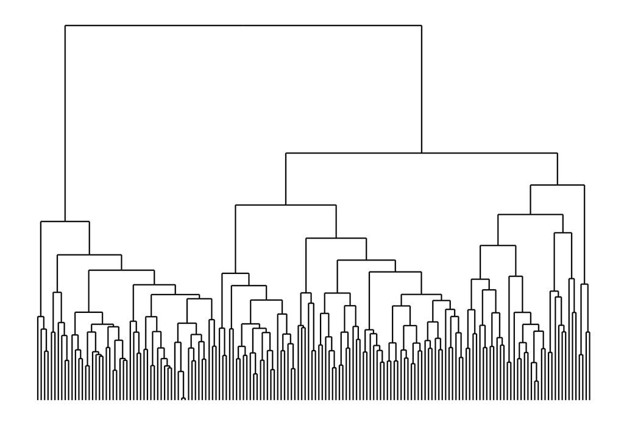

```r
clustering_data<-vkor_variants[vkor_variants$class=="missense",] %>%
group_by(position)

clustering_data<-dplyr::select(clustering_data,position,end,abundance_score)
clustering_data$position<-as.factor(clustering_data$position)

#use spread from tidy r to cast from long form to wide form
clustering_data_wide<-spread(clustering_data, end, abundance_score)
clustering_data_wide<-as.data.frame(clustering_data_wide)
row.names(clustering_data_wide)<-clustering_data_wide$position
clustering_data_wide<-clustering_data_wide[,2:21]
clustering_data_wide_matrix<-as.matrix(clustering_data_wide)
# find distance matrix
d <- dist(as.matrix(clustering_data_wide))
hc <- hclust(d, "complete")
dend<-as.dendrogram(hc)
dend_order<-unique(sort(clustering_data$position))[order.dendrogram(dend)]
#reordering dend_order to pivot around node of groups 3 and 4
dend_order<-as.character(c(33,37,30,35,26,106,123,107,127,128, 7,6,4,11,2,3,129,68,53,58,151,162,47,72,104,103,152,81,79,60,84,138,155,124,163,156,160,154,157,158,40,153,93,113,116,31,56,34,46,135,99,61,139,136,14,21,76,133,86,111,143,146,140,112,115,105,137,18,109, 114, 85,22,94,92,17,24,50,117,149,134,27,41,97,122,108,82,147,150,13,95,89,90,121,96,118,65,78,10,12,131,5,75,45,70,54,63,144,32,48,28,125,69,126,101,8,66,80,29,43,91,120,148,36,49,55,83,119, 15,20,87,39,59,25,159,161,9,51,23,42,98,67,73,52,57,77,62,64,71,74,44,142,100,38,130,132,16,102,110,19,88,141,145))
#updated dendrograms
dend<-dendextend::rotate(dend, dend_order)

position_cluster_dendrogram<-ggdendrogram(hc, rotate = FALSE, size = 2)
ddata <- dendro_data(dend, type = "rectangle")
p <- ggplot(segment(ddata)) +geom_segment(aes(x = x, y = y, xend = xend, yend = yend)) + theme_dendro()
clustering_data$end <- factor(clustering_data$end, levels = c("A","V","I","L","M","F","Y","W","S","T","N","Q","C","G","P","R","H","K","D","E"))
plot(p)
```

```r
ggsave("Output/position_cluster_dendrogram.pdf", p,height = 1, width = 6)

#cut dendrogram to isolate four groups of mutational patterns
cluster_assignments<-cutree(hc,k=4)

#color according to cluster
dend1 <- color_branches(dend, k = 4, col =c("#7b3294","#c2a5cf","#a6dba0","#008837"))
dend1<-highlight_branches_lwd(dend1,1)
pdf("Output/colored_dendrogram.pdf",
    width =8.03,
    height = 3)
plot(dend1,
     xaxt="n",
     yaxt="n",
     ann=FALSE)
dev.off()
```

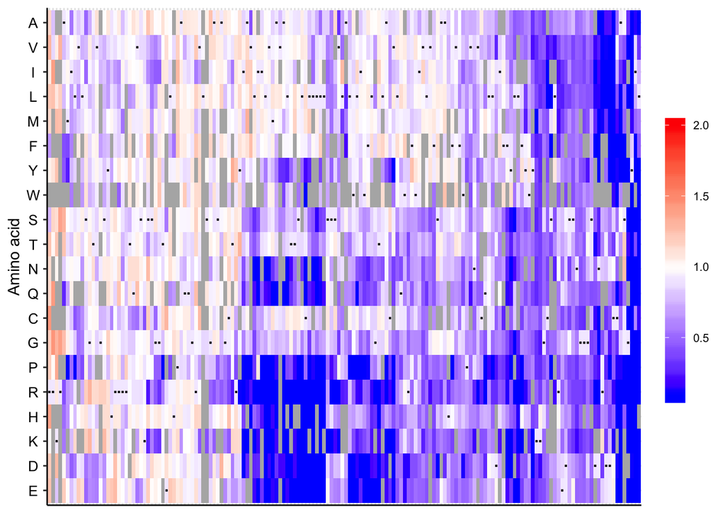

```r
#add 1 here because indexing starts at 1, put numbering in VKOR starts at 2 for this dataset (1st M not present)
cluster_1_indices<-which(cluster_assignments==1)
cluster_1_positions<-as.numeric(cluster_1_indices) + 1
cluster_1_positions<-paste(cluster_1_positions,collapse="+")
cluster_2_indices<-which(cluster_assignments==2)
cluster_2_positions<-as.numeric(cluster_2_indices) + 1
cluster_2_positions<-paste(cluster_2_positions,collapse="+")
cluster_3_indices<-which(cluster_assignments==3)
cluster_3_positions<-as.numeric(cluster_3_indices) + 1
cluster_3_positions<-paste(cluster_3_positions,collapse="+")
cluster_4_indices<-which(cluster_assignments==4)
cluster_4_positions<-as.numeric(cluster_4_indices) + 1
cluster_4_positions<-paste(cluster_4_positions,collapse="+")

dend_heatmap_aa_order <- c("A","V","I","L","M","F","Y","W","S","T","N","Q","C","G","P","R","H","K","D","E")

dend_heatmap<- ggplot() +
geom_tile(data = missing_combinations, aes(x = factor(position), y = end), fill = "grey70") +
geom_tile(data = subset(vkor_variants, (class == "missense") & abundance_score > vkor_lower_bound_abundance & abundance_score < vkor_upper_bound_abundance), aes(x = factor(position), y = end, fill = abundance_score)) +
geom_tile(data = subset(vkor_variants, (class == "missense") & abundance_score >= vkor_upper_bound_abundance), aes(x = factor(position), y = end, fill = abundance_score)) +
geom_tile(data = subset(vkor_variants, (class == "missense") & abundance_score <= vkor_lower_bound_abundance), aes(x = factor(position), y = end), fill = "blue") +
geom_tile(data = wtseqframe, aes(x = factor(position), y= end, fill = abundance_score)) +
geom_point(data = wtseqframe, aes(x = factor(position), y = end), shape = 15, size = 0.4) +
xlab(NULL) +scale_x_discrete(limits=dend_order,labels=dend_order)+ scale_y_discrete(limits = rev(dend_heatmap_aa_order)) +ylab(NULL) +
scale_fill_gradientn(colours = c("blue","white","red"), values = rescale(c(vkor_lower_bound_abundance,vkor_upper_bound_abundance,2)), limits=c(vkor_lower_bound_abundance,2)) +
  theme(axis.text.x=element_blank(),
        axis.text.y=element_text(size=10,color="black", hjust=0.5),
        axis.ticks.x=element_blank(),
        panel.grid.major = element_line(colour = "grey90"),
        legend.title = element_blank(),
        legend.text = element_text(size = 8,color="black"),
        legend.key.width=unit(0.5,"cm"),
        legend.key.height = unit(1.4,"cm"))+ylab("Amino acid")+labs(fill = "Abundance score")
plot(dend_heatmap)
```

```r
ggsave("Output/heatmap_in_dendrogram_order.pdf", dend_heatmap,height = 3, width = 7.55)
```

#### Figure 4b: Create pymol script

```r
# Create a vector of commands common to all pymol scripting I'll be doing
pymol_setup <- c()
# Import the PDB and do initial setup steps
pymol_setup <- append(pymol_setup, c("reinitialize","load itasser_vkor_model1.pdb","bg_color white","set opaque_background, 0","hide all","set ray_trace_mode, 1"))
# Create individual objects for vkor and the substrate
pymol_setup <- append(pymol_setup, c("create vkor, not resn HOH","delete itasser_vkor_model1","color white, vkor","show cartoon, vkor","orient vkor","set cartoon_gap_cutoff, 0"))
# Set the view to a common useful orientation
pymol_vkor_standard_view<-c("orient vkor","set_view (0.656203687,0.527281523,0.539783299,-0.593606174,0.802352965,-0.062142376,-0.465864658,-0.279636621,0.839497745,-0.000038132,-0.000523172,-186.717590332,62.718372345,60.053791046,59.686286926,-107.184852600,480.856170654,-20.000000000)")

fileConn<-file("Output/pymol_vkor_setup.pml")
writeLines(c(pymol_setup,pymol_vkor_standard_view,sep=""), fileConn)
close(fileConn)
```

#### Figure 4b: Coloring positions based on membership in hierarchical clustering dendrogram

```r
#Use hierarchical cluster assignments to automate coloring of positions in Pymol
pymol_custom_color<-c()
pymol_custom_color<-append(pymol_custom_color,paste("set_color mycol1,[123,50,148]"))
pymol_custom_color<-append(pymol_custom_color,paste("set_color mycol2,[194,165,207]"))
pymol_custom_color<-append(pymol_custom_color,paste("set_color mycol3,[166,219,160]"))
pymol_custom_color<-append(pymol_custom_color,paste("set_color mycol4,[0,136,55]"))
pymol_color_cluster1<-c()
pymol_color_cluster1<-append(pymol_color_cluster1,paste("create cluster_1, vkor and resi ",gsub(", ","+",toString(cluster_1_positions))," and not name c+n+o", sep= ""))
pymol_color_cluster1<-append(pymol_color_cluster1,c("hide all","color mycol1, cluster_1","set_bond stick_radius,0.85, cluster_1","show sticks, cluster_1","show cartoon, vkor"))
pymol_color_cluster2<-c()
pymol_color_cluster2<-append(pymol_color_cluster2,paste("create cluster_2, vkor and resi ",gsub(", ","+",toString(cluster_2_positions))," and not name c+n+o", sep= ""))
pymol_color_cluster2<-append(pymol_color_cluster2,c("hide all","color mycol2, cluster_2", "set_bond stick_radius,0.85, cluster_2", "show sticks, cluster_2","show cartoon, vkor"))
pymol_color_cluster3<-c()
pymol_color_cluster3<-append(pymol_color_cluster3,paste("create cluster_3, vkor and resi ",gsub(", ","+",toString(cluster_3_positions))," and not name c+n+o", sep= ""))
pymol_color_cluster3<-append(pymol_color_cluster3,c("hide all","color mycol3, cluster_3","set_bond stick_radius,0.85, cluster_3","show sticks, cluster_3","show cartoon, vkor"))
pymol_color_cluster4<-c()
pymol_color_cluster4<-append(pymol_color_cluster4,paste("create cluster_4, vkor and resi ",gsub(", ","+",toString(cluster_4_positions))," and not name c+n+o", sep= ""))
pymol_color_cluster4<-append(pymol_color_cluster4,c("hide all","color mycol4, cluster_4","set_bond stick_radius,0.85, cluster_4", "show sticks, cluster_4","show cartoon, vkor"))

fileConn<-file("Output/pymol_vkor_hierarchical_cluster1_colors.pml")
writeLines(c(pymol_custom_color,pymol_color_cluster1,pymol_vkor_standard_view,
 paste("png ",markdown_directory,"/plots/pymol_vkor_cluster1.png,height=8cm, width=7cm, dpi=300, ray=1",sep="")
 ), fileConn)
close(fileConn)

fileConn<-file("Output/pymol_vkor_hierarchical_cluster2_colors.pml")
writeLines(c(pymol_custom_color,pymol_color_cluster2,pymol_vkor_standard_view,
 paste("png ",markdown_directory,"/plots/pymol_vkor_cluster2.png, height=8cm, width=7cm, dpi=300, ray=1",sep="")
 ), fileConn)
close(fileConn)

fileConn<-file("Output/pymol_vkor_hierarchical_cluster3_colors.pml")
writeLines(c(pymol_custom_color,pymol_color_cluster3,pymol_vkor_standard_view,
 paste("png ",markdown_directory,"/plots/pymol_vkor_cluster3.png, height=8cm, width=7cm, dpi=300, ray=1",sep="")
 ), fileConn)
close(fileConn)

fileConn<-file("Output/pymol_vkor_hierarchical_cluster4_colors.pml")
writeLines(c(pymol_custom_color,pymol_color_cluster4,pymol_vkor_standard_view,
 paste("png ",markdown_directory,"/plots/pymol_vkor_cluster4.png, height=8cm, width=7cm, dpi=300, ray=1",sep="")
 ), fileConn)
close(fileConn)
```

#### Figure 4c: RSA by mutatational tolerance group

[figure not shown]

```r
#RSA by hierarchical clustering membership group
rsa_clustering_plot<-ggplot(vkor_positions,aes(x=hc_cluster_membership,y=rsa))+geom_boxplot(aes(fill=hc_cluster_membership))+scale_fill_manual(values=c("#7b3294","#c2a5cf","#a6dba0","#008837"))+ylab("Relative solvent accessibility")+xlab("Cluster")+
  theme(axis.text.x =element_text(size=10,color="black"),
        axis.text.y=element_text(size=10,color="black"),
        axis.title.y=element_text(size=12,color="black"),
        axis.title.x=element_text(size=12,color="black"),
        legend.position = "none")
plot(rsa_clustering_plot)
```

```r
ggsave("Output/rsa_by_group_plot.pdf", rsa_clustering_plot,height = 2.25, width = 2.25)
```

#### Figure 4d: VKOR missense distribution is trimodal and segregates by domain

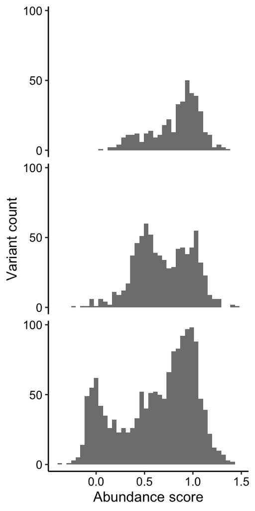

```r
missense_variants<-vkor_variants[vkor_variants$class=="missense",]

#Histogram of VKOR missense variants colored by position in protein: TM/ER/cytosol
vkor_score_by_domain_histogram_abundance<-ggplot(missense_variants,aes(x=abundance_score))+geom_histogram(bins=40,fill="grey50")+ scale_y_continuous(breaks=seq(0,100,50))+facet_grid(domain ~ .)+xlab("Abundance score")+ylab("Variant count")+
  theme(axis.text.x =element_text(size=10,color="black"),
        axis.text.y=element_text(size=10,color="black"),
        axis.title=element_text(size=12,color="black"),
        strip.text = element_blank())
print(vkor_score_by_domain_histogram_abundance)
```

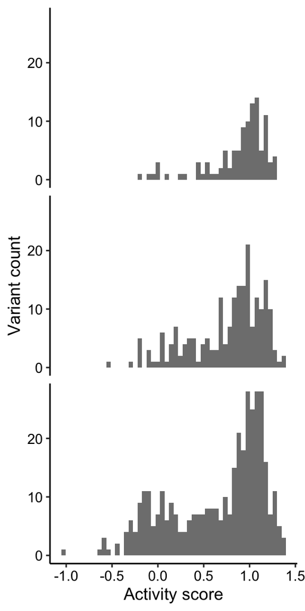

```r
ggsave(file="Output/vkor_missense_abundance_histogram_by_domain_facet_grid.pdf",vkor_score_by_domain_histogram_abundance, height = 2.5, width = 2.25)
#Histogram of VKOR missense variants colored by position in protein: TM/ER/cytosol
vkor_score_by_domain_histogram_activity<-ggplot(missense_variants,aes(x=activity_score))+geom_histogram(bins=50,fill="grey50")+ theme(panel.grid.major = element_blank(), panel.grid.minor = element_blank(),panel.background = element_blank(),legend.position = "none")+facet_grid(domain ~ .)+xlab("Activity score")+ylab("Variant count")+
  theme(axis.text.x =element_text(size=10,color="black"),
        axis.text.y=element_text(size=10,color="black"),
        axis.title=element_text(size=12,color="black"),
        strip.text = element_blank())
print(vkor_score_by_domain_histogram_activity)
```

```r
ggsave(file="Output/vkor_missense_activity_histogram_by_domain_facet_grid.pdf",vkor_score_by_domain_histogram_activity, height = 2.5, width = 2.25)
```

#### Figure 5: Create a score that is ratio of activity and abundance (specific activity) to define active site residues

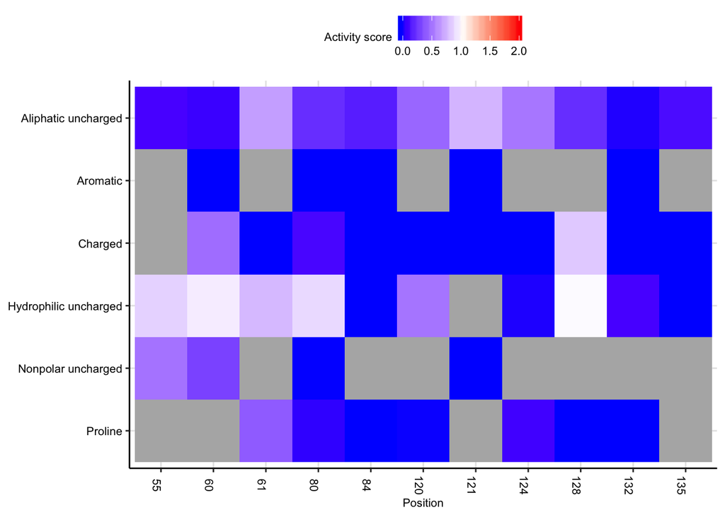

```r
#Rescale activity and abundance scores so they are both from 0 to 1
missense_variants$activity_score_rescaled<-NA
missense_variants$abundance_score_rescaled<-NA
missense_variants$activity_score_rescaled<-rescale(missense_variants$activity_score,to=c(0,1))
missense_variants$abundance_score_rescaled<-rescale(missense_variants$abundance_score,to=c(0,1))

#Calculate activity to abundance for every variant
missense_variants$ratio_activity_abundance<-(missense_variants$activity_score_rescaled)/(missense_variants$abundance_score_rescaled)

vkor_position_specific_activity_histogram<-ggplot()+geom_histogram(data=vkor_positions,bins=50,aes(x=ratio_activity_abundance))+geom_histogram(data=subset(vkor_positions, position %in% c(132,135)),bins=50,aes(x=ratio_activity_abundance),fill="blue")+scale_x_continuous(lim=c(-1,10))+geom_vline(xintercept = quantile(vkor_positions$ratio_activity_abundance,0.125,na.rm = TRUE), linetype = 2)+
  theme(panel.background = element_rect(fill = "white"),
        axis.text.x =element_text(size=10,color="black"),
        axis.text.y=element_text(size=10,color="black"),
        axis.title=element_text(size=12,color="black"))+
  xlab("Specific activity")+
  ylab("Count")
ggsave(file = "Output/vkor_position_specific_activity_histogram.pdf", vkor_position_specific_activity_histogram, height = 3, width = 3)
active_site_positions<-vkor_positions[vkor_positions$ratio_activity_abundance < quantile(vkor_positions$ratio_activity_abundance,0.125,na.rm=TRUE) & vkor_positions$variants_scored_activity>3,"position"]
active_site_positions<-active_site_positions[!is.na(active_site_positions)]
active_site_positions<-unique(active_site_positions)

#mini heatmaps for active site positions
active_site_full_variant_heatmap <- ggplot() +
geom_tile(data = subset(missing_combinations,position %in% active_site_positions), aes(x = factor(position), y = end), fill = "grey70") +
geom_tile(data = subset(vkor_variants, position %in% active_site_positions & (class == "missense" | class == "nonsense") & abundance_score > vkor_lower_bound_abundance & abundance_score < vkor_upper_bound_abundance), aes(x = factor(position), y = end, fill = abundance_score)) +
geom_tile(data = subset(vkor_variants, position %in% active_site_positions & (class == "missense" | class == "nonsense") & abundance_score >= vkor_upper_bound_abundance), aes(x = factor(position), y = end, fill = abundance_score)) +
geom_tile(data = subset(vkor_variants, position %in% active_site_positions & (class == "missense" | class == "nonsense") & abundance_score <= vkor_lower_bound_abundance), aes(x = factor(position), y = end), fill = "blue") +
geom_tile(data = subset(wtseqframe, position %in% active_site_positions), aes(x = factor(position), y= end, fill = abundance_score)) +
geom_point(data = subset(wtseqframe, position %in% active_site_positions), aes(x = factor(position), y = end), shape = 15, size = 0.4) +scale_x_discrete(limits=as.character(active_site_positions))+ scale_y_discrete(limits = unique(rev(missing_combinations$end)))+
scale_fill_gradientn(colours = c("blue","white","red"), values = rescale(c(vkor_lower_bound_abundance,vkor_upper_bound_abundance,2)), limits=c(vkor_lower_bound_abundance,2)) +xlab("Position")+ylab("Amino acid")+
  theme(panel.background = element_rect(fill = "white"),
        panel.grid.major = element_line(colour = "grey90"),
        axis.text.x =element_text(size=8,color="black", angle=-90, vjust=0.95),
        axis.text.y=element_text(size=6,color="black",hjust=0.5),
        axis.title=element_text(size=8,color="black"),
        legend.title = element_text(size=8),
        legend.text = element_text(size=8),
        legend.position = "top")+ labs(fill = "Abundance score")
ggsave(file = "Output/active_site_full_variant_abundance_heatmap.pdf", active_site_full_variant_heatmap, height = 3, width = 2.5)

#Make a heatmap of active site activity scores where the amino acid classes are collapsed
clustering_data<-vkor_variants[vkor_variants$position %in% active_site_positions,] %>%
  group_by(position)
clustering_data<-clustering_data[clustering_data$end!="X",]
groupColumns=c("position","mut_class")
class_clustering_data<-ddply(clustering_data, groupColumns, function(X) data.frame(class_avg=mean(X$activity_score, na.rm = TRUE)))

#recast so that first column is position and then subsequent columns are scores with each AA class
class_clustering_data$position<-factor(class_clustering_data$position)
colnames(class_clustering_data)[3] <- "activity_score"
#use spread from tidy r to cast from long form to wide form
class_clustering_data_wide<-spread(class_clustering_data, mut_class, activity_score)
class_clustering_data_wide<-as.data.frame(class_clustering_data_wide)
row.names(class_clustering_data_wide)<-class_clustering_data_wide$position
class_clustering_data_wide<-class_clustering_data_wide[,2:7]
class_clustering_data$mut_class<-factor(class_clustering_data$mut_class,levels=sort(c("Charged","Aliphatic uncharged","Aromatic","Proline","Hydrophilic uncharged","Nonpolar uncharged")))

#need to figure out which positions have data missing
class_vector <- rep(c("Charged","Aliphatic uncharged","Aromatic","Proline","Hydrophilic uncharged","Nonpolar uncharged"),15)
class_full_combinations <- crossing(active_site_positions,class_vector)
colnames(class_full_combinations)<-c("position","mut_class")
class_full_combinations$class_variant <- paste(class_full_combinations$position,class_full_combinations$mut_class,sep="")
class_clustering_data$class_variant <- paste(class_clustering_data$position,class_clustering_data$mut_class,sep="")
class_clustering_data<-class_clustering_data[class_clustering_data$activity_score != "NaN",]
class_missing_combinations <- class_full_combinations[!(class_full_combinations$class_variant %in% class_clustering_data$class_variant),]

active_site_activity_heatmap<- ggplot() +
  geom_tile(data = class_missing_combinations, aes(x = factor(position), y = mut_class), fill = "grey70") +
  geom_tile(data = subset(class_clustering_data, activity_score > vkor_lower_bound_activity & activity_score < vkor_upper_bound_activity), aes(x = factor(position), y = mut_class, fill = activity_score)) +
  geom_tile(data = subset(class_clustering_data, activity_score >= vkor_upper_bound_activity), aes(x = factor(position), y = mut_class, fill = activity_score)) +
  geom_tile(data = subset(class_clustering_data, activity_score <= vkor_lower_bound_activity), aes(x = factor(position), y = mut_class), fill = "blue") +scale_x_discrete(limits=as.character(active_site_positions))+ scale_y_discrete(limits = (rev(sort(unique(class_clustering_data$mut_class))))) +
  scale_fill_gradientn(colours = c("blue","white","red"), values = rescale(c(vkor_lower_bound_activity,vkor_upper_bound_activity,2)), limits=c(vkor_lower_bound_activity,2), name = "Activity score") + xlab("Position")+
  theme(axis.text.x=element_text(size=8,colour="black",angle=-90),
        axis.text.y=element_text(size=8,colour="black"),
        panel.background = element_rect(fill = "white"),
        panel.grid.major = element_line(colour = "grey90"),
        legend.text = element_text(size=8),
        legend.title = element_text(size=8),
        axis.title.x = element_text(size=8),
        axis.title.y = element_blank(),
        legend.position = "top")+labs(fill = "Abundance score")
plot(active_site_activity_heatmap)
```

```r
ggsave("Output/active_site_activity_heatmap.pdf", active_site_activity_heatmap,height = 3, width = 3)
```

#### Figure 5b: Active site definition analysis

```r
# Make a new vector for active site positions identified in Czogalla et al. paper (https://www.nature.com/articles/nsmb.3338)
czogalla_active_site_positions<-c(30,55,59,78,80,84,87,88,90,112,113,116,120,123,124,128)

#what is intersection of data active site and czogalla active site
pymol_overlap_active_site_positions<-intersect(active_site_positions,czogalla_active_site_positions)
vkor_data_unique_active_site<-active_site_positions[!(active_site_positions %in% pymol_overlap_active_site_positions)]
czogalla_data_unique_active_site<-czogalla_active_site_positions[!(czogalla_active_site_positions %in% pymol_overlap_active_site_positions)]

# Make a new vector for unique active site positions from my data
pymol_vkor_active_site <- c()
# Make a command that creates a new object of only the unique active site positions from my data
pymol_vkor_active_site <- append(pymol_vkor_active_site, paste("create active_site, vkor and resi ",gsub(", ","+",toString(active_site_positions)),"", sep= ""))
pymol_vkor_active_site <- append(pymol_vkor_active_site, paste("create cysteines, vkor and resi ",gsub(", ","+",toString(c("132","135"))),"", sep= ""))
# Represent active site with magenta orange spheres, cysteines as aqua
pymol_vkor_active_site <- append(pymol_vkor_active_site, c("show spheres, active_site","color magenta, active_site","set sphere_transparency=0.2, active_site","orient vkor"))
pymol_vkor_active_site <- append(pymol_vkor_active_site, c("show spheres, cysteines","color greencyan, cysteines","set sphere_transparency=0.2, cysteines","orient vkor"))

pymol_czogalla_active_site <- c()
# Make a command that creates a new object of only the active site positions from the Czogalla et al. paper
pymol_czogalla_active_site <- append(pymol_czogalla_active_site, paste("create czogalla_active_site, vkor and resi ",gsub(", ","+",toString(czogalla_data_unique_active_site)),"", sep= ""))
# Represent active site with yellow orange spheres
pymol_czogalla_active_site <- append(pymol_czogalla_active_site, c("show spheres, czogalla_active_site","color yelloworange, czogalla_active_site","set sphere_transparency=0.2, czogalla_active_site","orient vkor"))

fileConn<-file("Output/pymol_czogalla_active_site.pml")
writeLines(c(pymol_czogalla_active_site,pymol_vkor_standard_view,
 paste("png ",markdown_directory,"/plots/pymol_czogalla_active_site.png, height= 7cm, width=7cm, dpi=300, ray=1",sep="")
 ), fileConn)
close(fileConn)

fileConn<-file("Output/pymol_vkor_data_active_site.pml")
writeLines(c(pymol_vkor_active_site,pymol_vkor_standard_view,
 paste("png ",markdown_directory,"/plots/pymol_vkor_data_active_site.png, height= 16cm, width=16cm, dpi=300, ray=1",sep="")
 ), fileConn)
close(fileConn)
```

#### Figure 5c: Zoomed in active site with two alternate views

```r
#hide residues 55-65 so you can see cysteines more clearly for first view
# pymol_vkor_zoomin_view_1<-c("orient vkor","set_view (0.649258852,0.490363389,0.581377149,-0.537385225,0.836697400,-0.105592541,-0.538217247,-0.243861586,0.806743801,-0.000210064,-0.000124089,-97.850257874,68.515419006,72.530281067,57.014923096,-196.138122559,391.903015137,-20.000000000)")
# pymol_vkor_zoomin_view_2<-c("orient vkor","set_view (-0.362280518,0.793299854,-0.489306092,0.327178210,0.599793792,0.730202436,0.872752786,0.104450509,-0.476838022,-0.000210064,-0.000124089,-97.850257874,68.515419006,72.530281067,   57.014923096,-196.138122559,391.903015137,-20.000000000 )")

pymol_vkor_zoomin_view<-c("orient vkor","set_view (0.736129344,0.654963374,0.170693919,-0.676630080,0.718404412,    0.161448613,-0.016885519,-0.234344751,0.972007394,0.000016127,0.000047784,-64.231903076,65.288925171,69.705024719,59.814834595,49.754718781,78.692863464,-20.000000000)")


active_site_zoomin_1<-c()
active_site_zoomin_1 <- append(active_site_zoomin_1, paste("create active_site, vkor and resi ",gsub(", ","+",toString(active_site_positions)),"", sep= ""))
active_site_zoomin_1 <- append(active_site_zoomin_1, paste("create cysteines, vkor and resi ",gsub(", ","+",toString(c("43","132","135"))),"", sep= ""))
# Represent active site with magenta orange spheres, cysteines as aqua
active_site_zoomin_1 <- append(active_site_zoomin_1, c("show spheres, active_site","color magenta, active_site","set sphere_transparency=0.2, active_site"))
active_site_zoomin_1 <- append(active_site_zoomin_1, c("show spheres, cysteines","color greencyan, cysteines","set sphere_transparency=0.2, cysteines"))
active_site_zoomin_1 <- append(active_site_zoomin_1, c("show sticks, active_site"))
active_site_zoomin_1 <- append(active_site_zoomin_1, paste("hide everything, vkor and resi ",gsub(", ","+",toString(seq(57,65,1))),"", sep= ""))

fileConn<-file("Output/pymol_vkor_data_active_site_zoomin_1.pml")
writeLines(c(active_site_zoomin_1,pymol_vkor_zoomin_view,
 paste("png ",markdown_directory,"/plots/pymol_vkor_data_active_site_zoomin_1.png, height=10 cm,width=16cm, dpi=300, ray=1",sep=""),"rotate y, 120",paste("png ",markdown_directory,"/plots/pymol_vkor_data_active_site_zoomin_2.png, height=10 cm,width=16cm, dpi=300, ray=1",sep="")
 ), fileConn)
close(fileConn)

# fileConn<-file("Output/pymol_vkor_data_active_site_zoomin_2.pml")
# writeLines(c(active_site_zoomin_1,pymol_vkor_zoomin_view_2,
#  paste("png ",markdown_directory,"/plots/pymol_vkor_data_active_site_zoomin_2.png, height=10 cm, width=14cm, dpi=300, ray=1",sep="")
#  ), fileConn)
# close(fileConn)
```

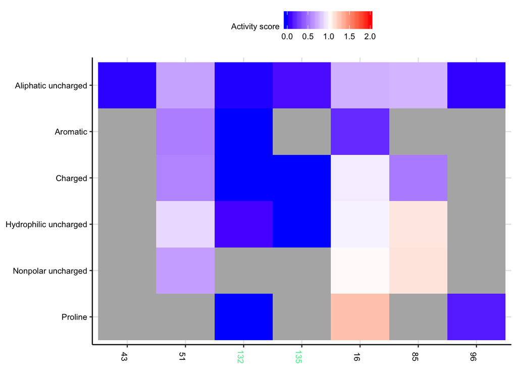

```r
vkor_cysteines<-vkor_variants[vkor_variants$position %in% c(16,85,96,43,51,132,135),]
vkor_cysteines$position<-as.character(vkor_cysteines$position)
vkor_cysteines$position <- factor(vkor_cysteines$position, levels = c("43","51","132","135","16","85","96"))
vkor_cysteines_summarized<-ddply(vkor_cysteines,~position,summarise,mean_abundance=mean(abundance_score),se_abundance=sd(abundance_score)/sqrt(length(abundance_score)),mean_activity=mean(activity_score, na.rm = TRUE),se_activity=sd(activity_score, na.rm = TRUE)/sqrt(length(activity_score)))

#Make a heatmap of cysteine abundance scores where the amino acid classes are collapsed
clustering_data<-vkor_cysteines %>%
  group_by(position)
clustering_data<-clustering_data[clustering_data$end!="X",]
groupColumns=c("position","mut_class")
class_clustering_data<-ddply(clustering_data, groupColumns, function(X) data.frame(class_avg=mean(X$abundance_score)))

#recast so that first column is position and then subsequent columns are scores with each AA class
class_clustering_data$position<-factor(class_clustering_data$position)
colnames(class_clustering_data)[3] <- "abundance_score"
#use spread from tidy r to cast from long form to wide form
class_clustering_data_wide<-spread(class_clustering_data, mut_class, abundance_score)
class_clustering_data_wide<-as.data.frame(class_clustering_data_wide)
row.names(class_clustering_data_wide)<-class_clustering_data_wide$position
class_clustering_data_wide<-class_clustering_data_wide[,2:7]
class_clustering_data$mut_class<-factor(class_clustering_data$mut_class,levels=sort(c("Charged","Aliphatic uncharged","Aromatic","Proline","Hydrophilic uncharged","Nonpolar uncharged")))

#then build abundance heatmap with collapsed classes
dend_order<-unique(class_clustering_data$position)
cysteine_abundance_heatmap<- ggplot() +
  geom_tile(data = subset(class_clustering_data, abundance_score > vkor_lower_bound_abundance & abundance_score < vkor_upper_bound_abundance), aes(x = factor(position), y = mut_class, fill = abundance_score)) +
  geom_tile(data = subset(class_clustering_data, abundance_score >= vkor_upper_bound_abundance), aes(x = factor(position), y = mut_class, fill = abundance_score)) +
  geom_tile(data = subset(class_clustering_data, abundance_score <= vkor_lower_bound_abundance), aes(x = factor(position), y = mut_class), fill = "blue") +
  xlab(NULL) +scale_x_discrete(limits=dend_order,labels=dend_order)+ scale_y_discrete(limits = (rev(sort(unique(class_clustering_data$mut_class))))) +  ylab(NULL) +
  scale_fill_gradientn(colours = c("blue","white","red"), values = rescale(c(vkor_lower_bound_abundance,vkor_upper_bound_abundance,2)), limits=c(vkor_lower_bound_abundance,2), name = "Abundance score") +
  theme(axis.text.x=element_text(size=8,angle=-90,colour=(c("black","black","seagreen2","seagreen2","black","black","black"))),
        axis.text.y=element_text(size=8,colour="black"),
        panel.background = element_rect(fill = "white"),
        panel.grid.major = element_line(colour = "grey90"),
        legend.position="top",
        legend.text = element_text(size=8),
        legend.title = element_text(size=8))
ggsave("Output/cysteine_abundance_heatmap.pdf", cysteine_abundance_heatmap,height = 3, width = 3)

#Make a heatmap of cysteine activity scores where the amino acid classes are collapsed
clustering_data<-vkor_cysteines %>%
  group_by(position)
clustering_data<-clustering_data[clustering_data$end!="X",]
groupColumns=c("position","mut_class")
class_clustering_data<-ddply(clustering_data, groupColumns, function(X) data.frame(class_avg=mean(X$activity_score, na.rm = TRUE)))

#recast so that first column is position and then subsequent columns are scores with each AA class
class_clustering_data$position<-factor(class_clustering_data$position)
colnames(class_clustering_data)[3] <- "activity_score"
#use spread from tidy r to cast from long form to wide form
class_clustering_data_wide<-spread(class_clustering_data, mut_class, activity_score)
class_clustering_data_wide<-as.data.frame(class_clustering_data_wide)
row.names(class_clustering_data_wide)<-class_clustering_data_wide$position
class_clustering_data_wide<-class_clustering_data_wide[,2:7]
class_clustering_data$mut_class<-factor(class_clustering_data$mut_class,levels=sort(c("Charged","Aliphatic uncharged","Aromatic","Proline","Hydrophilic uncharged","Nonpolar uncharged")))

#need to figure out which positions have data missing
class_vector <- rep(c("Charged","Aliphatic uncharged","Aromatic","Proline","Hydrophilic uncharged","Nonpolar uncharged"),7)
class_full_combinations <- as.data.frame(cbind(c(16,85,96,43,51,132,135),class_vector))
colnames(class_full_combinations)<-c("position","mut_class")
class_full_combinations$class_variant <- paste(class_full_combinations$position,class_full_combinations$mut_class,sep="")
class_clustering_data$class_variant <- paste(class_clustering_data$position,class_clustering_data$mut_class,sep="")
class_clustering_data<-class_clustering_data[class_clustering_data$activity_score != "NaN",]
class_missing_combinations <- class_full_combinations[!(class_full_combinations$class_variant %in% class_clustering_data$class_variant),]

#then build activity heatmap with collapsed classes
dend_order<-unique(class_clustering_data$position)
a <- ifelse(class_clustering_data$position%in% c(43,51,132,135), "seagreen2", "black")
cysteine_activity_heatmap<- ggplot() +
  geom_tile(data = class_missing_combinations, aes(x = factor(position), y = mut_class), fill = "grey70") +
  geom_tile(data = subset(class_clustering_data, activity_score > vkor_lower_bound_activity & activity_score < vkor_upper_bound_activity), aes(x = factor(position), y = mut_class, fill = activity_score)) +
  geom_tile(data = subset(class_clustering_data, activity_score >= vkor_upper_bound_activity), aes(x = factor(position), y = mut_class, fill = activity_score)) +
  geom_tile(data = subset(class_clustering_data, activity_score <= vkor_lower_bound_activity), aes(x = factor(position), y = mut_class), fill = "blue") +
  xlab(NULL) +scale_x_discrete(limits=dend_order,labels=dend_order)+ scale_y_discrete(limits = (rev(sort(unique(class_clustering_data$mut_class))))) +  ylab(NULL) +
  scale_fill_gradientn(colours = c("blue","white","red"), values = rescale(c(vkor_lower_bound_activity,vkor_upper_bound_activity,2)), limits=c(vkor_lower_bound_activity,2), name = "Activity score") +
  theme(axis.text.x=element_text(size=8,angle=-90,colour=(c("black","black","seagreen2","seagreen2","black","black","black"))),
        axis.text.y=element_text(size=8,colour="black"),
        panel.background = element_rect(fill = "white"),
        panel.grid.major = element_line(colour = "grey90"),
        legend.position = "top",
        legend.text = element_text(size=8),
        legend.title = element_text(size=8))
plot(cysteine_activity_heatmap)
```

```r
ggsave("Output/cysteine_activity_heatmap.pdf", cysteine_activity_heatmap,height = 3, width = 3)
```

#### Figure 6a: Warfarin resistance variants

```r
wr_list<-c("W5X","A26P","A26T","L27V","H28Q","V29L","A34P","D36G","D36Y","A41S","V45A","S52L","S52W","V54L","S56F","R58G","W59R","W59C","W59L","V66G","V66M","H68Y","G71A","N77S","N77Y","I123N","L128R","Y139H")


wr_classifications<-subset(vkor_variants[vkor_variants$variant %in% wr_list,],select=c("variant","abundance_score","abundance_se","abundance_class","activity_score","activity_se","activity_class"))
```

#### Figure 6: Human variants analysis

```r
#Import human variant data
combined_human_var_dataset<-read.csv("human_variants_abundance_and_activity_scores.csv",header=TRUE)
```

#### Figure 6a: Human variants Venn diagram

```r
human_variant_venn<-venn.diagram(
    x = list(
        gnomAD = c(unique(combined_human_var_dataset[combined_human_var_dataset$dataset=="gnomad","variant"])),
        ClinVar = c(unique(combined_human_var_dataset[combined_human_var_dataset$dataset=="clinvar","variant"])),
        Color = c(unique(combined_human_var_dataset[combined_human_var_dataset$dataset=="color_genomics","variant"])),
        WR = c(wr_list)
        ),
    filename = NULL,
    col = "black",
    lty = "solid",
    lwd = 2,
    fill = c("cornflowerblue", "green", "yellow", "darkorchid1"),
    alpha = 0.50,
    label.col = c("orange", "white", "darkorchid4", "white", "white", "white", "white", "white", "darkblue", "white", "white", "white", "white", "darkgreen", "white"),
    cex = 1,
    fontfamily = "sans",
    fontface = "bold",
    cat.col = c("darkblue", "darkgreen", "orange", "darkorchid4"),
    cat.cex = 1,
    cat.fontfamily = "sans"
    );
ggsave("Output/vkor_human_variants_venn.pdf", human_variant_venn,height = 3, width = 3)
```

#### Figure 6b: Abundance class histogram by class of variant

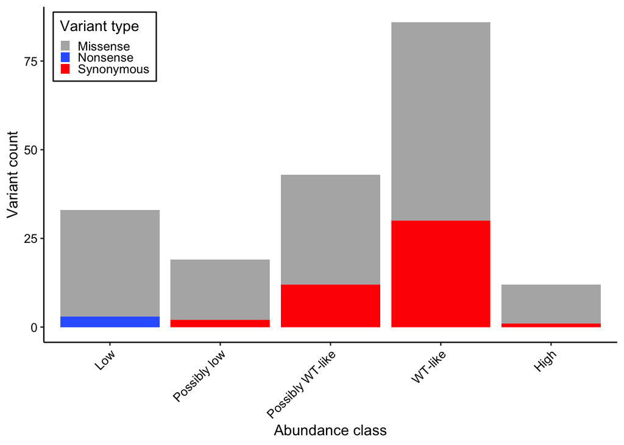

```r
human_variants_class_abundance_histogram<-ggplot(data=subset(combined_human_var_dataset, abundance_class != "unknown"))+
  geom_histogram(stat="count",aes(x=abundance_class,fill=class))+
  scale_x_discrete(limits=c("low","possibly_low","possibly_wt-like","wt-like","high"),labels=c("Low","Possibly low","Possibly WT-like","WT-like","High"))+
  scale_fill_manual(values=c("grey70", "#3366ff","#FF0000"),name = "Variant type",labels=c("Missense","Nonsense","Synonymous"))+
  theme(legend.justification = c(0.02, 0.98),
        legend.position = c(0.02, 0.98),
        legend.title = element_text(size=12),
        legend.text = element_text(size=10),
        legend.background = element_rect(colour = 'black', fill = 'white', linetype='solid'),
        axis.text.x=element_text(size=10,angle=45,color="black",hjust = 1),
        axis.text.y=element_text(size=10,color="black"),
        legend.key.size = unit(0.3, "cm"),
        axis.title=element_text(size=12,color="black"))+
  xlab("Abundance class")+
  ylab("Variant count")
plot(human_variants_class_abundance_histogram)
```

```r
ggsave(file="Output/human_variants_class_abundance_histogram.pdf",human_variants_class_abundance_histogram,height = 3.5, width = 4)
```

#### Figure 6c: Abundance class histogram of human variants

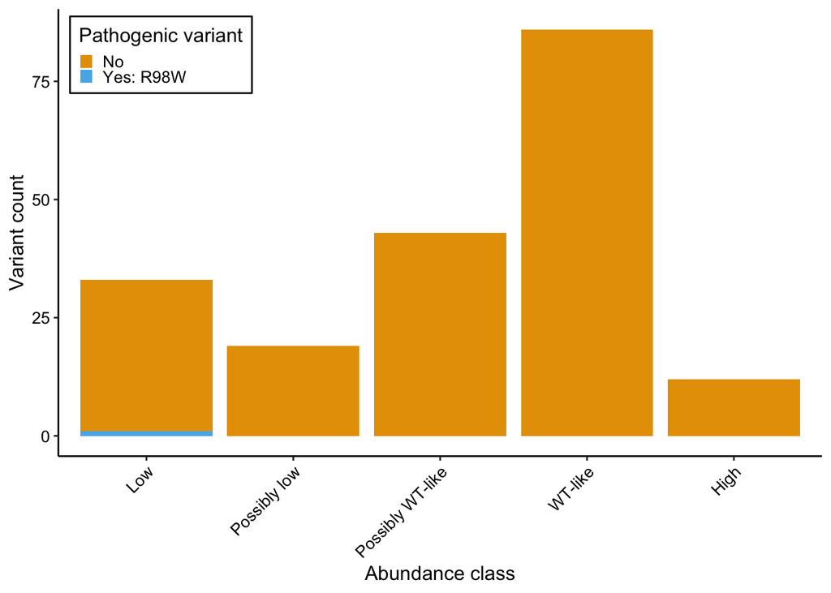

```r
#make a figure showing all variants from these databases broken out by class and colored by database
custom_colorscale <- c("low" = "#3366ff","possibly_low" = "#b3d9ff","possibly_wt-like" = "#ffcccc","wt-like" = "#F8766D","high" = "brown")

combined_human_variants_abundance_histogram<-ggplot(data=subset(combined_human_var_dataset, abundance_class != "unknown"))+
  geom_histogram(stat="count",aes(x=abundance_class,fill=literature_WR_variant))+
  scale_x_discrete(limits=c("low","possibly_low","possibly_wt-like","wt-like","high"),labels=c("Low","Possibly low","Possibly WT-like","WT-like","High"))+
  scale_fill_manual(values=c("#E69F00", "#56B4E9"),name = "Pathogenic variant",labels=c("No","Yes: R98W"))+
  theme(legend.justification = c(0.02, 0.98),
        legend.position = c(0.02, 0.98),
        legend.title = element_text(size=12),
        legend.text = element_text(size=10),
        legend.background = element_rect(colour = 'black', fill = 'white', linetype='solid'),
        axis.text.x=element_text(size=10,angle=45,color="black",hjust = 1),
        axis.text.y=element_text(size=10,color="black"),
        legend.key.size = unit(0.3, "cm"),
        axis.title=element_text(size=12,color="black"))+
  xlab("Abundance class")+
  ylab("Variant count")
plot(combined_human_variants_abundance_histogram)
```

```r
ggsave(file="Output/combined_human_variants_histogram_abundance.pdf",combined_human_variants_abundance_histogram,height = 3.5, width = 4)
```

#### Figure 6c: Plot of warfarin resistance variants abundance scores

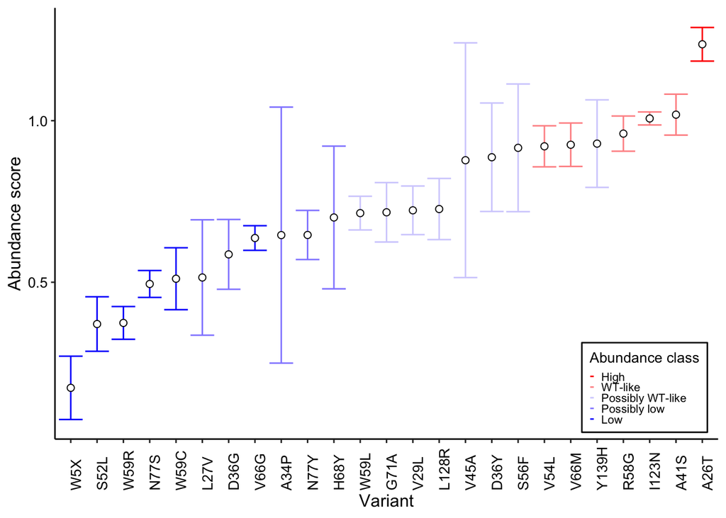

```r
wr_classifications$abundance_class<-factor(wr_classifications$abundance_class,levels=c("high","wt-like","possibly_wt-like","possibly_low","low"))

#point plot of wr variants abundance scores
wr_point_with_errobars_plot_abundance<-ggplot(wr_classifications, aes(x=reorder(variant, abundance_score),y=abundance_score))+
  geom_errorbar(aes(colour=abundance_class,ymin=abundance_score-abundance_se,ymax=abundance_score+abundance_se))+
  geom_point(shape = 21,colour="#000000",fill="#FFFFFF",size=2)+
  theme(axis.text.x=element_text(size=10,angle=90,color="black",hjust=0),
    axis.text.y=element_text(size=10,color="black"),
    panel.background = element_rect(fill = "white"),
    legend.title = element_text(size=10),
    legend.text = element_text(size=8),
    legend.justification = c(0.98,0.02),
    legend.position = c(0.98, 0.02),
    legend.background = element_rect(colour = 'black', fill = 'white', linetype='solid'),
    legend.key.size = unit(0.11, "cm"),
    axis.title=element_text(size=12,color="black"))+
  scale_color_manual(values=c("#FF0000","#FF9595","#D4D1FD","#938CFF","#0F00FC"),name = "Abundance class",labels=c("High","WT-like","Possibly WT-like","Possibly low","Low"))+
  xlab("Variant")+
  ylab("Abundance score")
plot(wr_point_with_errobars_plot_abundance)
```

```r
ggsave(file="Output/wr_variants_abundance_score_dot_plot.pdf",wr_point_with_errobars_plot_abundance,height = 3.5, width = 4)

ks.test(vkor_variants$abundance_score, wr_classifications$abundance_score)
```

```
##
##  Two-sample Kolmogorov-Smirnov test
##
## data:  vkor_variants$abundance_score and wr_classifications$abundance_score
## D = 0.1744, p-value = 0.438
## alternative hypothesis: two-sided
```

#### Figure 1–figure supplement 2: correlations between replicates for abundance

```r
scatterplot_correlation_fxn <- function(data, mapping, ...){
p <- ggplot(data = data, mapping = mapping) +
geom_point(alpha = 0.01)+ theme(axis.text.x = element_text(size=10,angle=-90,hjust=0.95))
p
}

vkor_variants_min <- vkor_variants[,c("class","abundance_score1","abundance_score2","abundance_score3","abundance_score4","abundance_score5","abundance_score6","abundance_score7")]

## experiment correlations
vkor_pearson_cor_matrix <- as.matrix(cor(vkor_variants_min[,c("abundance_score1","abundance_score2","abundance_score3","abundance_score4","abundance_score5","abundance_score6","abundance_score7")], use="pairwise.complete.obs", method = "pearson"))
paste("Average VKOR replicate correlation Pearson's r:",round(mean(vkor_pearson_cor_matrix[-seq(1,nrow(vkor_pearson_cor_matrix)^2,nrow(vkor_pearson_cor_matrix)+1)]),2))
```

```
## [1] "Average VKOR replicate correlation Pearson's r: 0.73"
```

```r
vkor_spearman_cor_matrix <- as.matrix(cor(vkor_variants_min[,c("abundance_score1","abundance_score2","abundance_score3","abundance_score4","abundance_score5","abundance_score6","abundance_score7")], use="pairwise.complete.obs", method = "spearman"))
paste("Average VKOR replicate correlation Spearman's r:",round(mean(vkor_spearman_cor_matrix[-seq(1,nrow(vkor_spearman_cor_matrix)^2,nrow(vkor_spearman_cor_matrix)+1)]),2))
```

```
## [1] "Average VKOR replicate correlation Spearman's r: 0.7"
```

```r
vkor_scatterplot_matrix_pearson <- ggpairs(vkor_variants_min,columns = c("abundance_score1","abundance_score2","abundance_score3","abundance_score4","abundance_score5","abundance_score6","abundance_score7"), lower = list(continuous = scatterplot_correlation_fxn), upper=list(continuous = wrap("cor", size = 4, color="black")),method = "pearson"+theme(panel.grid.major = element_blank(), panel.grid.minor = element_blank(),panel.background = element_blank(), axis.line = element_line(colour = "black")))+theme(axis.text.x=element_text(size=10,angle=-90,hjust=0.95),axis.text.y = element_text(size=10))
ggsave(file = "Output/vkor_scatterplot_matrix_pearson_abundance.pdf", plot = vkor_scatterplot_matrix_pearson, height = 4, width = 4)
```

#### Figure 2–figure supplement 2: correlations between replicates for activity

```r
scatterplot_correlation_fxn <- function(data, mapping, ...){
p <- ggplot(data = data, mapping = mapping) +
geom_point(alpha = 0.1) + theme(axis.text.x = element_text(size=10,angle=-90,hjust=0.95))
p
}

vkor_variants_min <- vkor_variants[,c("class","activity_score4","activity_score5","activity_score6","activity_score7","activity_score8","activity_score9")]

## experiment correlations
vkor_pearson_cor_matrix <- as.matrix(cor(vkor_variants_min[,c("activity_score4","activity_score5","activity_score6","activity_score7","activity_score8","activity_score9")], use="pairwise.complete.obs", method = "pearson"))
paste("Average VKOR replicate correlation Pearson's r:",round(mean(vkor_pearson_cor_matrix[-seq(1,nrow(vkor_pearson_cor_matrix)^2,nrow(vkor_pearson_cor_matrix)+1)]),2))
```

```
## [1] "Average VKOR replicate correlation Pearson's r: 0.62"
```

```r
vkor_spearman_cor_matrix <- as.matrix(cor(vkor_variants_min[,c("activity_score4","activity_score5","activity_score6","activity_score7","activity_score8","activity_score9")], use="pairwise.complete.obs", method = "spearman"))
paste("Average VKOR replicate correlation Spearman's r:",round(mean(vkor_spearman_cor_matrix[-seq(1,nrow(vkor_spearman_cor_matrix)^2,nrow(vkor_spearman_cor_matrix)+1)]),2))
```

```
## [1] "Average VKOR replicate correlation Spearman's r: 0.56"
```

```r
vkor_scatterplot_matrix_pearson <- ggpairs(vkor_variants_min,columns = c("activity_score4","activity_score5","activity_score6","activity_score7","activity_score8","activity_score9"), lower = list(continuous = scatterplot_correlation_fxn),upper=list(continuous = wrap("cor", size = 4, color="black")), method = "pearson"+theme(panel.grid.major = element_blank(),panel.grid.minor = element_blank()))+theme(axis.text.x=element_text(size=10,angle=-90,hjust=0.95),axis.text.y = element_text(size=10))
ggsave(file = "Output/vkor_scatterplot_matrix_pearson_activity.pdf", plot = vkor_scatterplot_matrix_pearson, height = 4, width =4)
```

#### Figure 3–figure supplement 1: pymol script to overlay bacterial structure with EVcouplings folded VKOR model

```r
# Create a vector of commands common to all pymol scripting I'll be doing
pymol_setup <- c()
# Import the PDB and do initial setup steps
pymol_setup <- append(pymol_setup, c("reinitialize","fetch 4NV5","bg_color white","set opaque_background, 0","hide all","set ray_trace_mode, 1"))
# Create individual objects for vkor and the substrate
pymol_setup <- append(pymol_setup, c("create bacterial_vkor, chain A and resi 16-150 and not resn HOH","delete 4NV5","color grey70, bacterial_vkor","show cartoon, bacterial_vkor","orient bacterial_vkor","set cartoon_gap_cutoff, 0"))
#load EVcouplings folded VKOR and align
pymol_setup <- append(pymol_setup, c("load evcouplings_model.cif","color forest, evcouplings","align bacterial_vkor, evcouplings"))
# Set the view to a common useful orientation
pymol_vkor_standard_view<-c("orient bacterial_vkor","set_view (0.015495982,-0.900648355,-0.434266955,0.854856908,0.237211853,-0.461461723,0.518630743,-0.364085436,0.773603559,0.000000000,0.000000000, -178.687484741,0.031576157,-0.094556808,0.089496613,140.878570557,216.496398926,-20.000000000 )")

fileConn<-file("Output/EV_couplings_bacterial_vkor_align.pml")
writeLines(c(pymol_setup,pymol_vkor_standard_view,
 paste("png ",markdown_directory,"/plots/EV_couplings_bacterial_vkor_align_view1.png, height=10 cm,width=16cm, dpi=300, ray=1",sep=""),"rotate y, 120",paste("png ",markdown_directory,"/plots/EV_couplings_bacterial_vkor_align_view2.png, height=10 cm,width=16cm, dpi=300, ray=1",sep="")
 ), fileConn)
close(fileConn)
```

#### Figure 3–figure supplement 2: facet grid histograms by specific domain

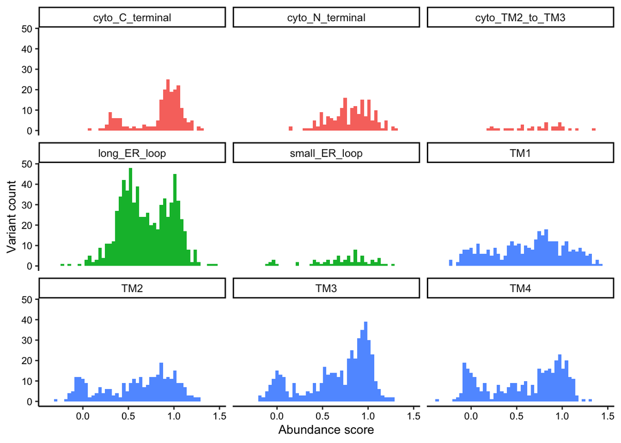

```r
#Histogram of VKOR missense variants colored by specific domain in protein
vkor_score_by_specific_domain_histogram<-ggplot(missense_variants,aes(x=abundance_score))+geom_histogram(bins=50,aes(fill=domain))+ theme(panel.grid.major = element_blank(), panel.grid.minor = element_blank(),panel.background = element_blank(),legend.position = "none",axis.text = element_text(size=8,colour="black"),axis.title = element_text(size=10,colour="black"))+facet_wrap(~specific_domain)+xlab("Abundance score")+ylab("Variant count")
print(vkor_score_by_specific_domain_histogram)
```

```r
ggsave(file="Output/vkor_missense_vars_histogram_by_specific_domain_facet_wrap.pdf",vkor_score_by_specific_domain_histogram, height=3, width = 4)
```

#### Figure 4–figure supplement 1: Show increased abundance variants (arginine and lysine analysis)

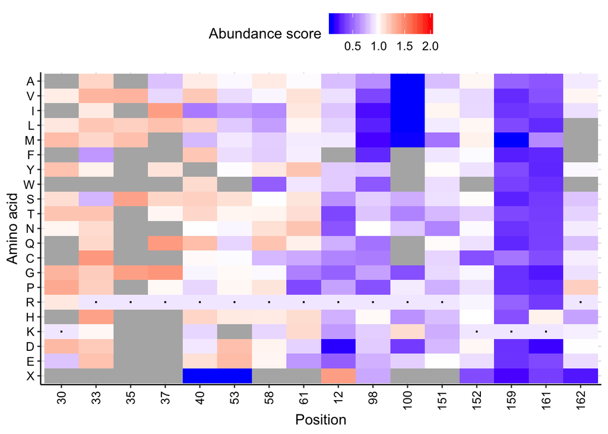

```r
RK_variants<-vkor_variants[vkor_variants$start %in% c("R","K"),]
#positions: 152 159 161  30 100  12 151 162  33  35  37  40  53  58  61  98
#want to compare abundance patterns for 30, 33, 35, 37 to rest of residues
#cytoplasmic: 12, 98,100,151,152,159,161,162
#ER lumenal:40,53,58,61

RK_order<-as.character(c(30,33,35,37,40,53,58,61,12,98,100,151,152,159,161,162))

wtseq <- "MGSTWGSPGWVRLALCLTGLVLSLYALHVKAARARDRDYRALCDVGTAISCSRVFSSRWGRGFGLVEHVLGQDSILNQSNSIFGCIFYTLQLLLGCLRTRWASVLMLLSSLVSLAGSVYLAWILFFVLYDFCIVCITTYAINVSLMWLSFRKVQEPQGKAKRH"
wtseqframe <- data.frame(seq(1,nchar(wtseq)))
wtseqframe$end <- rep("NA",nchar(wtseq))
for (x in 1:nchar(wtseq)){wtseqframe$end[x] <- substr(wtseq,x,x)}
wtseqframe$abundance_score <- vkor_variants[vkor_variants$class == "wt","abundance_score"]
colnames(wtseqframe) <- c("position","end","abundance_score")

position_vector <- seq(1:nchar(wtseq))
aa_vector <- c("A","V","I","L","M","F","Y","W","S","T","N","Q","C","G","P","R","H","K","D","E","X")
full_combinations <- as.vector(outer(position_vector, aa_vector, paste, sep=""))
missing_combinations <- data.frame(full_combinations[!(full_combinations %in% substr(subset(vkor_variants, !is.na(abundance_score))$variant,2,10))]); colnames(missing_combinations) <- "variant"
missing_combinations$position <- gsub("[^0-9]","",missing_combinations$variant); missing_combinations$position <- as.numeric(missing_combinations$position)
missing_combinations$end <- gsub("[0-9]","",missing_combinations$variant); missing_combinations$end <- factor(missing_combinations$end, levels = c("A","V","I","L","M","F","Y","W","S","T","N","Q","C","G","P","R","H","K","D","E","X"))

RK_full_variant_heatmap <- ggplot() +
geom_tile(data = subset(missing_combinations,position %in% RK_order), aes(x = factor(position), y = end), fill = "grey70") +
geom_tile(data = subset(vkor_variants, position %in% RK_order & (class == "missense" | class == "nonsense") & abundance_score > vkor_lower_bound_abundance & abundance_score < vkor_upper_bound_abundance), aes(x = factor(position), y = end, fill = abundance_score)) +
geom_tile(data = subset(vkor_variants, position %in% RK_order & (class == "missense" | class == "nonsense") & abundance_score >= vkor_upper_bound_abundance), aes(x = factor(position), y = end, fill = abundance_score)) +
geom_tile(data = subset(vkor_variants, position %in% RK_order & (class == "missense" | class == "nonsense") & abundance_score <= vkor_lower_bound_abundance), aes(x = factor(position), y = end), fill = "blue") +
geom_tile(data = subset(wtseqframe, position %in% RK_order), aes(x = factor(position), y= end, fill = abundance_score)) +
geom_point(data = subset(wtseqframe, position %in% RK_order), aes(x = factor(position), y = end), shape = 15, size = 0.4) +
xlab(NULL) +scale_x_discrete(limits=RK_order,labels=RK_order)+ scale_y_discrete(limits = unique(rev(missing_combinations$end))) +ylab(NULL) +
scale_fill_gradientn(colours = c("blue","white","red"), values = rescale(c(vkor_lower_bound_abundance,vkor_upper_bound_abundance,2)), limits=c(vkor_lower_bound_abundance,2)) +
theme(panel.background = element_rect(fill = "white"),
panel.grid.major = element_line(colour = "grey90"))+xlab("Position")+ylab("Amino acid")+
  theme(panel.background = element_rect(fill = "white"),
        panel.grid.major = element_line(colour = "grey90"),
        axis.text.x =element_text(size=10,color="black",angle=90, hjust=0.95, vjust=0.5),
        axis.text.y=element_text(size=10,color="black"),
        axis.title=element_text(size=12,color="black"),
        legend.title = element_text(size=12),
        legend.text = element_text(size=10),
        legend.position = "top")+ labs(fill = "Abundance score")
plot(RK_full_variant_heatmap)
```

```r
ggsave(file = "Output/RK_full_variant_abundance_heatmap.pdf", RK_full_variant_heatmap, height = 4, width = 3)
```

#### Figure 4–figure supplement 2: Comparing VKOR trimodal abundance score distribution to PTEN and TPMT

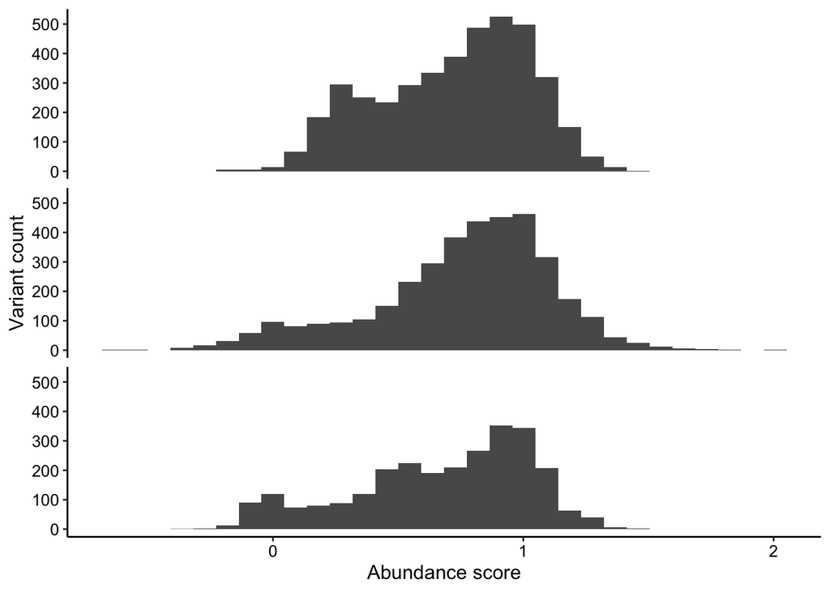

```r
pten_variants<-read.table("PTEN.tsv",sep="\t",header=TRUE)
tpmt_variants<-read.table("TPMT.tsv",sep="\t",header=TRUE)

#missense histogram comparison between VKOR, TPMT, and PTEN
missense_variants$protein<-"vkor"
pten_variants$protein<-"pten"
tpmt_variants$protein<-"tpmt"

#what columns do we want to put into
vkor_variants_to_combine <- missense_variants[,c("variant","class","abundance_class","end","abundance_score","abundance_se","protein")]
colnames(vkor_variants_to_combine)<-c("variant","class","abundance_class","end","score","se","protein")
pten_variants_to_combine<-pten_variants[,c("variant","class","abundance_class","end","score","se","protein")]
tpmt_variants_to_combine<-tpmt_variants[,c("variant","class","abundance_class","end","score","se","protein")]

all_variants_combined<-rbind(vkor_variants_to_combine,pten_variants_to_combine)
all_variants_combined<-rbind(all_variants_combined,tpmt_variants_to_combine)

combined_histogram_plot <- ggplot() + geom_histogram(data = subset(all_variants_combined, class == "missense" & !is.na(score)), aes(x = score)) +facet_grid(protein ~ .)+theme(axis.text=element_text(size=10,colour="black"),axis.title=element_text(size=12,colour="black"),strip.text = element_blank())+xlab("Abundance score")+ ylab("Variant count")
plot(combined_histogram_plot)
```

```r
ggsave(file="Output/missense_vars_histogram_pten_tpmt_vkor_combined.pdf",combined_histogram_plot, height = 3, width = 3)
```

#### Figure 5–figure supplement 3: Localization motif comparison

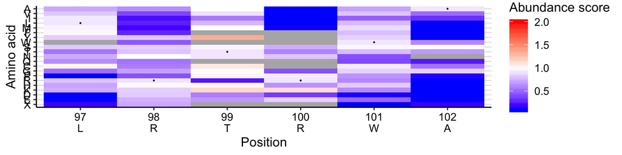

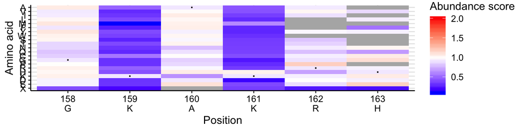

```
##
##  Wilcoxon rank sum test
##
## data:  sample(dilysine_variants[dilysine_variants$position %in% (c(158,  and dilysine_variants[dilysine_variants$position %in% (c(159, 161)),     160)), "abundance_score"], 40) and     "abundance_score"]
## W = 1563, p-value < 2.2e-16
## alternative hypothesis: true location shift is not equal to 0
```

```
##
##  Wilcoxon rank sum test
##
## data:  sample(diarginine_variants[diarginine_variants$position %in%  and diarginine_variants[diarginine_variants$position %in% (c(98,     (c(99, 101)), "abundance_score"], 36) and     100)), "abundance_score"]
## W = 865, p-value = 0.01412
## alternative hypothesis: true location shift is not equal to 0
```